# BMS31004 Bioinformatics for Biomedical Science - Week 4

Module Coordinator Mark Dunning

# Learning Objectives

- How can we visualise sample-to-sample relationships in our dataset?
- How is the result of a PCA interpreted?
- How can we look at the distribution of a particular gene?
- What commands are used in `DESeq2` to generate differential expression results?

Lets start by re-capping the processing we went through to start the analysis of the dataset

```r
library(readr)
library(tximport)
library(DESeq2)
library(dplyr)

dirs <- list.files("salmon_quant/")

quant_files <- list.files("salmon_quant/",pattern="quant.sf.gz",recursive = TRUE,full.names = TRUE)
names(quant_files) <- dirs

tx2gene <- read_csv("tx2gene.csv",col_names = FALSE)

txi <- tximport(quant_files,
                type="salmon",
                tx2gene = tx2gene,
                ignoreTxVersion = TRUE)

sampleInfo <- read_csv("meta_data/sampleInfo.csv")

dds <- DESeqDataSetFromTximport(txi,
                                colData = sampleInfo,
                                design = ~Treated)
```

The object `dds` will now contain the counts from the dataset along with the metadata. The counts themselves can be accessed using `counts`.

```r
## head is a commonly-used function to print the first six rows of a data frame
counts(dds) %>% head
```

```
                1_CTR_BC_2 2_TGF_BC_4 3_IR_BC_5 4_CTR_BC_6 5_TGF_BC_7 6_IR_BC_12
ENSG00000000003       1579       1547      1342       1704       1395       1264
ENSG00000000005          0          0         0          0          0          0
ENSG00000000419       1774       1775      1866       1809       1921       1776
ENSG00000000457        698        617       601        733        662        537
ENSG00000000460        246        309       116        224        255        108
ENSG00000000938         10          5        11          6          1          2
                7_CTR_BC_13 8_TGF_BC_14 9_IR_BC_15
ENSG00000000003        1556        1370       1269
ENSG00000000005           0           0          1
ENSG00000000419        1797        1482       1980
ENSG00000000457         751         593        628
ENSG00000000460         245         289        127
ENSG00000000938          19           4          8
```

We have previously seen how to obtain the total number of reads for a sample by calculating the column sums of this *count matrix*.

```r
## 1e6 is a shortcut for one million
counts(dds) %>% colSums / 1e6
```

```
 1_CTR_BC_2  2_TGF_BC_4   3_IR_BC_5  4_CTR_BC_6  5_TGF_BC_7  6_IR_BC_12 7_CTR_BC_13
   37.96648    42.30252    33.30004    39.40193    37.71644    32.59979    34.27317
8_TGF_BC_14  9_IR_BC_15
   38.52221    36.47827
```

# Sample-to-Sample comparisons

## Visualising count distributions

We typically use a `boxplot` to visualise difference the distributions of the columns of a numeric data frame. We have previously created such plots using `ggplot2`. Unfortunately using `ggplot2` to visualise our counts is not straightforward, so we will use the `boxplot` function from base R.

Applying the `boxplot` function to the raw counts from our dataset reveals something about the nature of the data; the distributions are dominated by a few genes with very large counts.

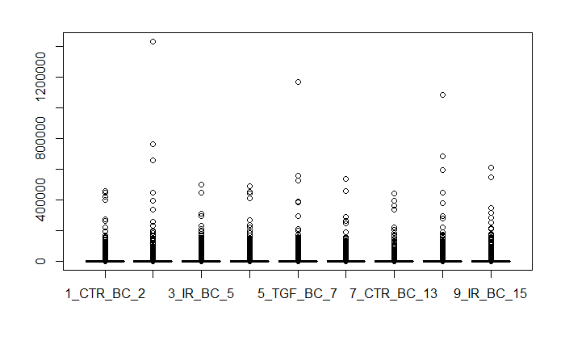

```r
boxplot(counts(dds))
```

We can use the `vst` or `rlog` function from `DESeq2`to put the data on a more convenient scale for visualisation. It will also correct for some other features of the data that we will explore later.

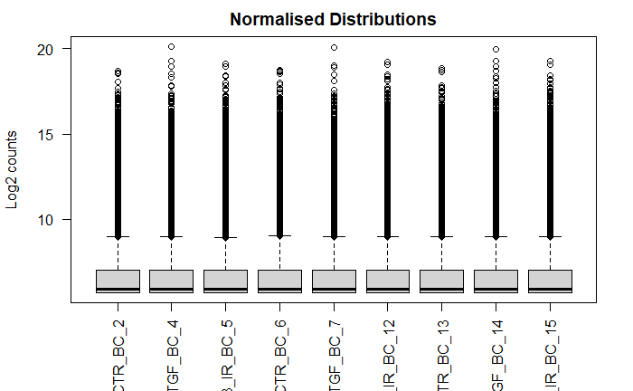

```r
# Get log2 counts
vsd <- vst(dds)
# Check distributions of samples using boxplots
boxplot(assay(vsd), xlab="", ylab="Log2 counts",las=2,main="Normalised Distributions")
```

The purpose of the boxplot is to check that we get the same *distribution* of counts for each sample. What this doesn’t tell us is if the same gene measured on different samples is *roughly* the same.

This time we can use `ggplot2` to plot the counts for one sample directly against the other.

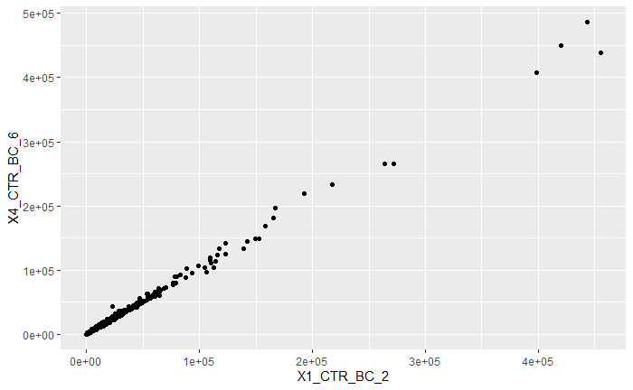

```r
library(ggplot2)
## make a data frame from the counts so we can plot with ggplot2
df <- data.frame(counts(dds))

ggplot(df, aes(x = `X1_CTR_BC_2`, y = `X4_CTR_BC_6`)) + geom_point()
```

Each individual dot on the plot is a *gene* and the x- and y- coordinates represent the counts in the two respective samples. It looks like the counts are reasonably well correlated to each other. This would expected as we have chosen two samples that belong to the same biological group. We can also use the same type of plot to compare samples from different groups.

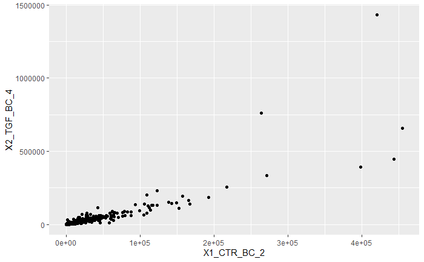

```r
ggplot(df, aes(x = `X1_CTR_BC_2`, y = `X2_TGF_BC_4`)) + geom_point()
```

The plot is possibly a bit noisier; hopefully reflecting the variability between the two samples. For the plots we have just made we could create corresponding statistics to quantify the degree of association. For example the correlation coefficient can be calculated using the `cor` function (see the exercises for this week).

Whilst such visualisations are useful in increasing our understanding of the data, we need a more automated approach to quality assessment. It would clearly be a lot of coding to create scatter plots for all pairwise combinations of samples. Our focus should be on interpreting the data; so any shortcuts we can take using existing functions in DESeq2 are desirable.

## Principal components Analysis (PCA)

In genomic data, we have a large number of variables which are often highly correlated. [(Principal Components Analysis) PCA](http://setosa.io/ev/principal-component-analysis/) is one of many *dimension-reduction* techniques that can remove redundancy and give a smaller more manageable set of variables. In summary it can help us to:-

- Reduce *dimensionality* of the data
- Decrease the *redundancy* of the data
- Filter the *noise* in the data
- *Compress* the data

See here for a nice explanation of PCA https://www.youtube.com/watch?v=0Jp4gsfOLMs

A PCA is an example of an unsupervised analysis, where we don’t need to specify the groups. If your experiment is well-controlled and has worked well, what we hope to see is that the greatest sources of variation in the data correspond to the treatments/groups we are interested in. It is also an incredibly useful tool for quality control and checking for outliers.

`DESeq2` has a convenient `plotPCA` function for making the PCA plot, which makes use of the `ggplot2` graphics package.

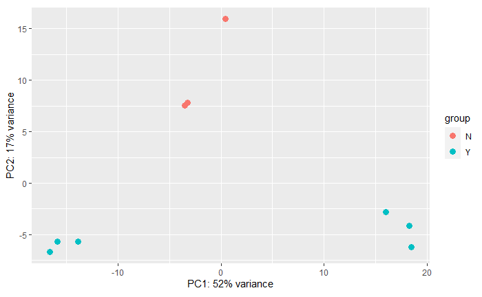

```r
plotPCA(vsd,intgroup="Treated")
```

There is also an option to return the values used in the plot for further exploration and customisation. Here we join the PCA results to the meta-data (`sampleinfo`) for plotting.

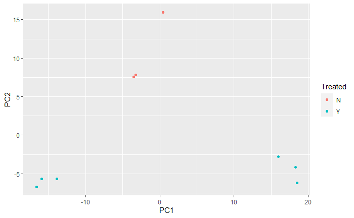

```r
library(dplyr)
library(ggplot2)
pca_data <- plotPCA(vsd,intgroup="Treated",returnData = TRUE) %>%
  dplyr::rename(Run = name) %>%
  left_join(sampleInfo)
  ggplot(pca_data,aes(x = PC1, y = PC2,col=Treated)) + geom_point()
```

# Exercise

- Is the `plotPCA` plot based on all genes in the dataset? How can we change how many genes are used for the PCA analysis? Does this significantly change the plot? (HINT: check the documentation for the `plotPCA` function.)
- Do the samples appear to be separated based on the type of treatment applied?
- What problems can you see with the metadata?
- Can you label the identify of each sample? Look for help on `geom_text`if you haven’t used it before

### Note about batch effects

In our unsupervised analysis we should see that the main source of variation is due to biological effects, and not technical variation such as when the libraries were sequenced. If we do observe high technical variation in our data, it is not a complete disaster provided that we have designed our experiment properly. In particular the [sva Bioconductor package](https://bioconductor.org/packages/release/bioc/vignettes/sva/inst/doc/sva.pdf) can correct for batch effects provided that representatives of the groups of interest appear in each batch. Alternatively, the batch or confounding factor may be incorporated into the differential expression analysis.

### Correcting the sample information

Here are a set of commands to create an updated sample sheet using the `stringr` package (part of `tidyverse`). We write a new file rather than over-writing the existing one.

```r
library(stringr)
library(dplyr)
sampleInfo %>%
mutate(condition = str_to_upper(condition)) %>%
write_tsv(file="meta_data/sampleInfo_corrected.txt")
```

## Exercise

**Exercise:** - Re-create the `DESeqDataset` object to include the corrected sample information - Re-run the plotPCA function on the new data and verify that the sample groups now look correct

# Visualising Gene-specific counts

Now that we have established that the expression profiles of our samples are broadly different between biological groups, we can turn our attention to which genes might be exhibiting changes in expression level. The counts themselves can be obtained by using the `counts` function, which gives a matrix of values with one row for each gene and a column for each sample

```r
counts(dds) %>% head
```

```
                1_CTR_BC_2 2_TGF_BC_4 3_IR_BC_5 4_CTR_BC_6 5_TGF_BC_7 6_IR_BC_12
ENSG00000000003       1579       1547      1342       1704       1395       1264
ENSG00000000005          0          0         0          0          0          0
ENSG00000000419       1774       1775      1866       1809       1921       1776
ENSG00000000457        698        617       601        733        662        537
ENSG00000000460        246        309       116        224        255        108
ENSG00000000938         10          5        11          6          1          2
                7_CTR_BC_13 8_TGF_BC_14 9_IR_BC_15
ENSG00000000003        1556        1370       1269
ENSG00000000005           0           0          1
ENSG00000000419        1797        1482       1980
ENSG00000000457         751         593        628
ENSG00000000460         245         289        127
ENSG00000000938          19           4          8
```

Individual genes can be interrogated using the standard subset syntax from base R; with the row index or gene name used to indicate the row of interest.

```r
## square brackets [] are used to extract particular rows and columns from a data frame
## second argument inside the [] is left blank so that all columns are printed

counts(dds)["ENSG00000000003",]
```

```
 1_CTR_BC_2  2_TGF_BC_4   3_IR_BC_5  4_CTR_BC_6  5_TGF_BC_7  6_IR_BC_12 7_CTR_BC_13
       1579        1547        1342        1704        1395        1264        1556
8_TGF_BC_14  9_IR_BC_15
       1370        1269
```

We could potentially use this data in a plot to compare counts between groups, but once again `DESeq2` provides a useful shortcut in the form of the `plotCounts` function. In this function we can specify a gene name of interest (which must be found somewhere in the row names of the count matrix) and a comparison (`intgroup`). The comparison name must be present in the sample information.

If you are unsure about what names can be used, you can retrieve the *metadata* that is stored with the DESeq dataset using the `colData` function.

```r
colData(dds)
```

```
DataFrame with 9 rows and 5 columns
                    Run   condition        Name Replicate  Treated
            <character> <character> <character> <numeric> <factor>
1_CTR_BC_2   1_CTR_BC_2         CTR       CTR_1         1        N
2_TGF_BC_4   2_TGF_BC_4         TGF       TGF_1         1        Y
3_IR_BC_5     3_IR_BC_5          IR        IR_1         1        Y
4_CTR_BC_6   4_CTR_BC_6         CTR       CTR_2         2        N
5_TGF_BC_7   5_TGF_BC_7         TGF       TGF_2         2        Y
6_IR_BC_12   6_IR_BC_12          IR        IR_2         2        Y
7_CTR_BC_13 7_CTR_BC_13         ctr       CTR_3         3        N
8_TGF_BC_14 8_TGF_BC_14         tgf       TGF_3         3        Y
9_IR_BC_15   9_IR_BC_15          ir        IR_3         3        Y
```

```r
colnames(colData(dds))
```

```
[1] "Run"       "condition" "Name"      "Replicate" "Treated"
```

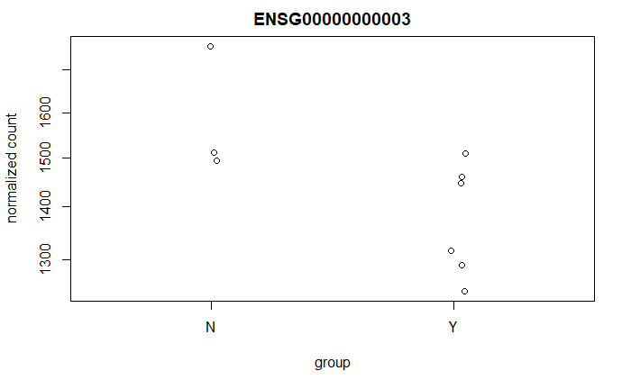

```r
## the intgroup argument must be in quotes, and match a column found in the colData output

plotCounts(dds, "ENSG00000000003", intgroup = "Treated")
```

The plot is not very inspiring, but it is a useful plot to quickly visualise the expression of a particular gene of interest (as we will see in the exercises it is possible to refine the plot using `ggplot2`). For example, we might have a gene identified in previous studies that we want to investigate.

We *could* use a t-test, or a non-parametric alternative, to assess whether the difference is significant or not, **but this would not be advised**.

```r
t.test(counts(dds)["ENSG00000000003",] ~ dds$Treated)
```

```
    Welch Two Sample t-test

data:  counts(dds)["ENSG00000000003", ] by dds$Treated
t = 3.972, df = 5.3139, p-value = 0.009393
alternative hypothesis: true difference in means between group N and group Y is not equal to 0
95 percent confidence interval:
  90.49302 406.50698
sample estimates:
mean in group N mean in group Y
         1613.0          1364.5
```

```r
wilcox.test(counts(dds)["ENSG00000000003",] ~ dds$Treated)
```

```
    Wilcoxon rank sum exact test

data:  counts(dds)["ENSG00000000003", ] by dds$Treated
W = 18, p-value = 0.02381
alternative hypothesis: true location shift is not equal to 0
```

# Differential expression with `DESeq2`

Now that we are happy that we have normalised the data and that the quality looks good, we can continue to testing for differentially expressed genes. There are a number of packages to analyse RNA-Seq data. Most people use `DESeq2` or `edgeR`. We will use `DESeq2` for the rest of this practical.

It would be a good idea to save the results of the pre-processing so we don’t have to repeat it every time.

```r
dir.create("Robjects/",showWarnings = FALSE)
saveRDS(dds, file="Robjects/dds.rds")
```

# The DESeq workflow in brief

We have previously defined the test condition using the `design` argument when we created the object. This can be checked using the `design` function.

Typically we decide the design for the analysis when we create the DESeq2 objects, but it can be modified prior to the differential expression analysis. The design tells `DESeq2` which sample groups to compare in the differential analysis. The name specified must correspond to a column in the sample information.

```r
colData(dds)
```

```
DataFrame with 9 rows and 5 columns
                    Run   condition        Name Replicate  Treated
            <character> <character> <character> <numeric> <factor>
1_CTR_BC_2   1_CTR_BC_2         CTR       CTR_1         1        N
2_TGF_BC_4   2_TGF_BC_4         TGF       TGF_1         1        Y
3_IR_BC_5     3_IR_BC_5          IR        IR_1         1        Y
4_CTR_BC_6   4_CTR_BC_6         CTR       CTR_2         2        N
5_TGF_BC_7   5_TGF_BC_7         TGF       TGF_2         2        Y
6_IR_BC_12   6_IR_BC_12          IR        IR_2         2        Y
7_CTR_BC_13 7_CTR_BC_13         ctr       CTR_3         3        N
8_TGF_BC_14 8_TGF_BC_14         tgf       TGF_3         3        Y
9_IR_BC_15   9_IR_BC_15          ir        IR_3         3        Y
```

```r
## note that the condition to be compared does not need to be in quote marks
design(dds) <- ~Treated
```

The counts that we have obtained via sequencing are subject to random sources of variation. The purpose of differential expression is to determine if potential sources of biological variation (e.g. counts observed from different sample groups) are greater than random noise.

The `DESeq` function runs a couple of processing steps automatically to adjust for different library size and gene-wise variability, which you can read about in the [DESeq2 vignette](http://bioconductor.org/packages/devel/bioc/vignettes/DESeq2/inst/doc/DESeq2.html#the-deseq2-model) and run some example code at the end of the next session.

```r
de_treated<- DESeq(dds)
de_treated
```

```
class: DESeqDataSet
dim: 57914 9
metadata(1): version
assays(6): counts avgTxLength ... H cooks
rownames(57914): ENSG00000000003 ENSG00000000005 ... ENSG00000284747
  ENSG00000284748
rowData names(22): baseMean baseVar ... deviance maxCooks
colnames(9): 1_CTR_BC_2 2_TGF_BC_4 ... 8_TGF_BC_14 9_IR_BC_15
colData names(5): Run condition Name Replicate Treated
```

The results of the analysis are not immediately accessible, but can be obtained using the `results` function. Each row is a particular gene measured in the study (i.e. all genes in the organism being studied) and each column reports some aspect of the differential expression analysis for that gene. Note that **all genes** are reported. At this stage the gene identifiers are not very informative, something we will fix in the next section.

The output of `results` can tell us the direction of the contrast that is being calculated (i.e. which group is used as a baseline). In this case all fold-changes are calculated relative to un-treated, or CTRL samples - which makes sense. We can change the baseline of our comparison if we need to.

```r
results(de_treated)
```

```
log2 fold change (MLE): Treated Y vs N
Wald test p-value: Treated Y vs N
DataFrame with 57914 rows and 6 columns
                   baseMean log2FoldChange     lfcSE      stat    pvalue      padj
                  <numeric>      <numeric> <numeric> <numeric> <numeric> <numeric>
ENSG00000000003 1447.265802     -0.2051187  0.121418 -1.689365 0.0911494  0.574408
ENSG00000000005    0.113575      0.5069982  3.533803  0.143471 0.8859182        NA
ENSG00000000419 1814.108471      0.0773555  0.189163  0.408936 0.6825867  0.950327
ENSG00000000457  645.735472     -0.1603703  0.124985 -1.283112 0.1994530  0.740864
ENSG00000000460  221.065743     -0.4662569  0.423195 -1.101753 0.2705689  0.800604
...                     ...            ...       ...       ...       ...       ...
ENSG00000284744    8.377622       0.381924  0.672894  0.567584  0.570318  0.924953
ENSG00000284745    0.000000             NA        NA        NA        NA        NA
ENSG00000284746    0.102422      -0.935671  3.533803 -0.264777  0.791181        NA
ENSG00000284747   29.068925      -0.333544  0.374367 -0.890956  0.372953  0.861365
ENSG00000284748    0.548454       2.181462  3.495590  0.624061  0.532587        NA
```

However, the output of `results` is not immediately useful. We would like to use the functions of `dplyr` to filter, sort and re-arrange the data. Fortunately, the authors have provided as argument that will output the results in a more useful format.

```r
results(de_treated,tidy = TRUE)
```

| row | baseMean | log2FoldChange | lfcSE | stat | pvalue | padj |
| --- | --- | --- | --- | --- | --- | --- |
| ENSG00000000003 | 1.447266e+03 | -0.2051186671 | 0.12141759 | -1.689365290 | 9.114945e-02 | 5.744078e-01 |
| ENSG00000000005 | 1.135747e-01 | 0.5069981555 | 3.53380296 | 0.143470975 | 8.859182e-01 | NA |
| ENSG00000000419 | 1.814108e+03 | 0.0773555295 | 0.18916296 | 0.408935923 | 6.825867e-01 | 9.503266e-01 |
| ENSG00000000457 | 6.457355e+02 | -0.1603702690 | 0.12498544 | -1.283111652 | 1.994530e-01 | 7.408640e-01 |
| ENSG00000000460 | 2.210657e+02 | -0.4662568847 | 0.42319536 | -1.101753311 | 2.705689e-01 | 8.006040e-01 |
| ENSG00000000938 | 7.645304e+00 | -1.2834914905 | 0.81271485 | -1.579264227 | 1.142755e-01 | 6.245194e-01 |
| ENSG00000000971 | 5.393851e+03 | -0.3191563981 | 0.14017505 | -2.276841723 | 2.279568e-02 | 3.250770e-01 |
| ENSG00000001036 | 3.649162e+03 | -0.1176690729 | 0.17483843 | -0.673016051 | 5.009371e-01 | 9.075119e-01 |
| ENSG00000001084 | 9.416370e+02 | -0.1174866522 | 0.20076272 | -0.585201525 | 5.584122e-01 | 9.226159e-01 |
| ENSG00000001167 | 1.276092e+03 | -0.0554945764 | 0.16067051 | -0.345393664 | 7.297984e-01 | 9.606068e-01 |

[output cut: 990 more lines]

## Save the results

```r
dir.create("Robjects/",showWarnings = FALSE)
saveRDS(de_treated, "Robjects/de_treated.rds")
```

## Exercise

**Exercise**: Use the appropriate `dplyr` functions to achieve the following:-

- Write the entire results table to a csv file
- Sort the differential expression results according to adjusted p-value
- Restrict the data to genes with adjusted p-value less than 0.05 and log2FoldChange > 1 or < -1

# Appendix (Optional) Visualisting count distributions using `ggplot2`

In the practical we use the base R `boxplot` function to compare the distribution of counts between different samples. Why do we say it is not straightforward to plot these counts using `ggplot2`? Consider the dimensions of the count matrix:-

```r
counts(dds) %>% head
```

```
                1_CTR_BC_2 2_TGF_BC_4 3_IR_BC_5 4_CTR_BC_6 5_TGF_BC_7 6_IR_BC_12
ENSG00000000003       1579       1547      1342       1704       1395       1264
ENSG00000000005          0          0         0          0          0          0
ENSG00000000419       1774       1775      1866       1809       1921       1776
ENSG00000000457        698        617       601        733        662        537
ENSG00000000460        246        309       116        224        255        108
ENSG00000000938         10          5        11          6          1          2
                7_CTR_BC_13 8_TGF_BC_14 9_IR_BC_15
ENSG00000000003        1556        1370       1269
ENSG00000000005           0           0          1
ENSG00000000419        1797        1482       1980
ENSG00000000457         751         593        628
ENSG00000000460         245         289        127
ENSG00000000938          19           4          8
```

And the format that the code to create a boxplot is usually written in

```r
ggplot(data, aes(x = ...., y=....)) + geom_boxplot()
```

**Take a bit of time to consider this before moving-on**. You do not need to write any code.

The issue is that the count matrix is in *wide* rather than *long* format. In other words, the counts for a particular gene go across the table rather than down. This present a problem for `ggplot2`. We can convert using one of the tools from `tidyr`. For more information on `tidyr`, see the package website

- https://tidyr.tidyverse.org/

The format of data required is something like…

| Gene | Sample | Expression |
| --- | --- | --- |
| A | Sample1 | 10.3 |
| A | Sample2 | 20.5 |

First we have to convert the counts from a matrix to a data frame.

```r
counts(dds) %>%
  as.data.frame
```

The `pivot_longer` function will do the task of converting from wide to long data. The arguments; which columns we have to convert (all in this case) and what we want to respective value and name columns to be.

```r
library(tidyr)
counts(dds) %>%
  as.data.frame %>%
  pivot_longer(cols=1:9,values_to="Expression",names_to="Sample")
```

| Sample | Expression |
| --- | --- |
| 1_CTR_BC_2 | 1579 |
| 2_TGF_BC_4 | 1547 |
| 3_IR_BC_5 | 1342 |
| 4_CTR_BC_6 | 1704 |
| 5_TGF_BC_7 | 1395 |
| 6_IR_BC_12 | 1264 |
| 7_CTR_BC_13 | 1556 |
| 8_TGF_BC_14 | 1370 |
| 9_IR_BC_15 | 1269 |
| 1_CTR_BC_2 | 0 |

[output cut: 990 more lines]

The data can then be passed directly to `ggplot` for plotting.

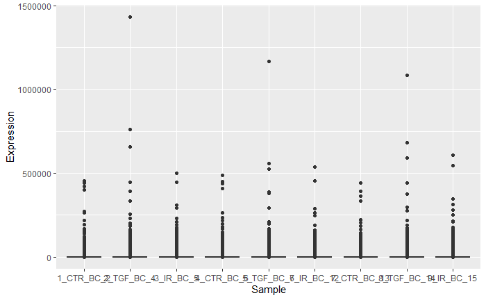

```r
library(tidyr)
counts(dds) %>%
  as.data.frame %>%
  pivot_longer(cols=1:9,values_to="Expression",names_to="Sample") %>%
  ggplot(aes(x = Sample, y = Expression)) + geom_boxplot()
```

As we saw, the plot isn’t particularly informative due to the scale. Instead we can plot the variance-stabilized counts using similar code

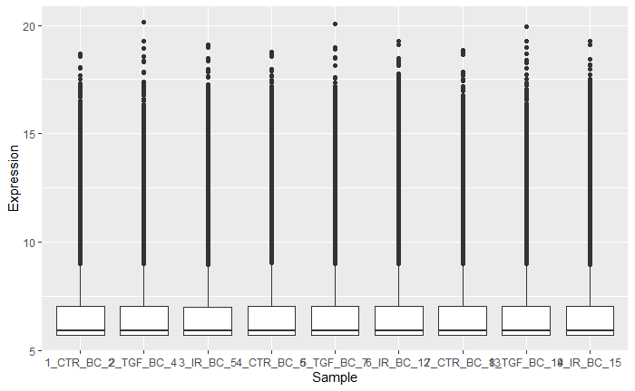

```r
library(tidyr)
assay(vsd) %>%
  as.data.frame %>%
  pivot_longer(cols=1:9,values_to="Expression",names_to="Sample") %>%
  ggplot(aes(x = Sample, y = Expression)) + geom_boxplot()
```